# Statistical Analysis of Pokémon Stats and Characteristics

Kellen Petersen and Jonathan Zhu

3/31/2022

# Abstract

We investigated a data set of Pokemon: a popular video game where creatures called Pokemon battle each other. Our interest lay in the Pokemon’s competitive stats, specifically their base stat total which is comprised of these stats sum. Performing an analysis of varience (ANOVA) test first, we found a significant differences at the 0.01 level exist between attack and every other stat, as well as between HP and defense and between speed and defense. Next, we made a linear model to predict base stat total excluding the competitive stats that would be too heavily correlated with it. We concluded that while our model does a decent job with predicting BST based on factors such as base experience, capture rate, and base happiness, it should still be used with some degree of caution, especially when trying to predict incredibly large base stat totals, because there were outliers in the constant variability of the residuals. Last, we made another linear model to predict speed based on the competitive stats of the Pokemon. Based on the linear regression, we deduced that all the base stats were significant parameters for predicting the Pokemon’s speed but overall did not do a good job.

# Introduction

Pokémon, originally Pocket Monsters (ポケットモンスター in Japanese) is a franchise first developed by Satoshi Tajiri in 1996 and has since become the highest-grossing media franchise of all time at approximately $92 billion USD. The franchise has developed 122 video games, over 1000 animated episodes, 23 animated films, and has sold over 34 billion trading cards, in addition to countless other money-making outlets such as plushies, figures, and other merchandise (these numbers are accurate as of writing).

The concept of Pokémon revolves around collecting creatures called Pokémon and having them battle against each other using various attacks called moves. In each battle, the objective is to reduce the HP (health points) of all the opponent’s Pokémon to zero. Moves do various damage depending both on the attributes of the moves and the stats of each Pokémon; namely, the attack and special attack of the attacking Pokémon, and the defense and special defense of the Pokémon being attacked.

Our chosen dataset is the dataset containing the names and information of all 898 Pokémon and their alternate forms introduced from the first game, Pokémon Red and Blue, to the 2019 games Pokémon Sword and Shield. The [dataset](https://www.kaggle.com/datasets/kylekohnen/complete-pokemon-data-set) was sourced from kaggle.com via Kyle Kohnen; the data itself were derived from Pokémon information sites such as pokeapi.co, pokemondb.net, serebii.net, [Bulbapedia](https://bulbapedia.bulbagarden.net/wiki/Main_Page), and the [Pokémon Wiki](https://pokemon.fandom.com/wiki/Pok%C3%A9mon_Wiki), which themselves derived data directly from the video games.

The dataset contains the following variables:

- The Pokémon’s name and number;
- The Pokémon’s type/s and ability/ies;
- The Pokémon’s competitive stats, including HP (Hit Points), Attack, Defense, Special Attack, Special Defense, and Speed;
- The Pokémon’s height and weight;
- The Pokémon’s genus (describes the Pokémon without using its name; for example, Pikachu is the Mouse Pokémon);
- The generation (game) in which the Pokémon was first introduced; for example, Pikachu was introduced in Generation 1 (Red and Blue) while Alcremie was introduced in Generation 8 (Sword and Shield)
- Whether or not the Pokémon is genderless, and if not, how often it is female;
- Whether or not the Pokémon is considered a Baby Pokémon, a Legendary Pokémon, or a Mythical Pokémon;
- Whether or not the entry corresponds to the Pokémon’s default form, and whether or not it is capable of switching forms;
- The Pokémon’s base experience level, which the games use to determine how much experience it yields upon defeat;
- The Pokémon’s base capture rate, which the games use to determine how likely a Pokémon can be captured in a given scenario;
- The Pokémon’s egg group/s (if two Pokémon have the same egg group, they can breed);
- The Pokémon’s egg cycles, which the games use to determine how many steps it would take to hatch this Pokémon from an egg;
- The Pokémon’s base happiness, which is the amount of happiness out of 255 the Pokémon has when first hatched or caught;
- Whether the Pokémon can evolve and the Pokémon it evolves from, if applicable;
- The Pokémon’s primary color and shape;
- The total amount of Pokémon with the same typing as itself, including itself;
- How effective each type is against the Pokémon.

In addition, we added another variable called BST, or Base Stat Total, which sums all the other stat values and is loosely a measure of how powerful a Pokémon is.

We specifically sought to investigate the question: **To what extent are a Pokémon’s stats connected both to each other and to other characteristics of the Pokémon?**

# Exploratory Data Analysis

## Prelimary Remarks

The Pokemon’s name will not be analyzed since it cannot be quantified.

The Pokemon’s number has no relation to any other stat by design and therefore will also not be investigated.

A Pokemon’s type effectiveness is a static variable that will also not be investigated since we have complete information about its actual value and how to predict it without any source of randomness.

The remaining Pokemon’s statistics that can be quantified and are related to at least one other statistic by design, but we are primary interested in the Pokemon’s competitive stats since that is what determines its usefulness in battle and we believe the most useful statistic to explore in this data set.

## Data Visualization

### Non-Stat Characteristics

Our preliminary exploration of the dataset involved the examination of relationships between variables we thought would have an intuitive relationship. We started by comparing the physical attributes of height and weight, since those have a linear relationship in humans:

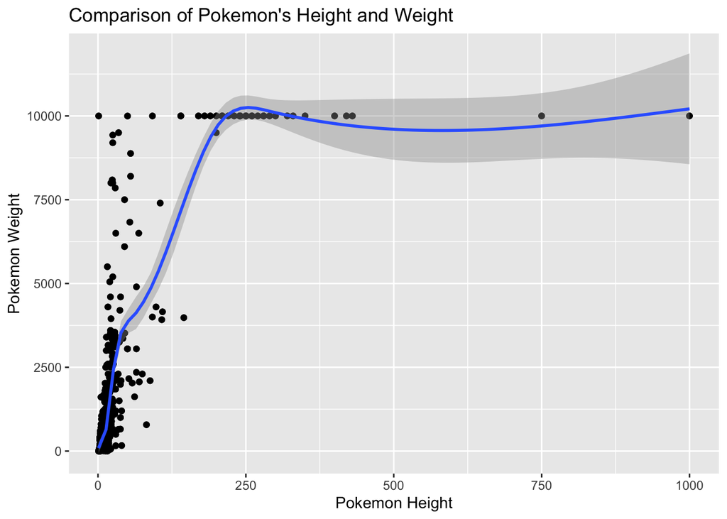

The figure shows no clear link between a Pokémon’s height and weight, which can be explained by the fact that Pokémon come in far more forms than humans. However, we calculate the correlation between the two variables as follows:

```
##
##  Pearson's product-moment correlation
##
## data:  pokemon$height and pokemon$weight
## t = 38.201, df = 1116, p-value < 2.2e-16
## alternative hypothesis: true correlation is not equal to 0
## 95 percent confidence interval:
##  0.7261838 0.7770963
## sample estimates:
##       cor
## 0.7527635
```

Running a Pearson’s correlation test between height and weight, two continuous variables, we can see there is a strong correlation between them, with the 95 perfect confidence interval falling between 0.72 and 0.77 (p-val: < 2.2e-16). However, this observation does not provoke many questions for us, so we will not investigate either characteristic further.

We next looked at the relationship these two variables have on a Pokémon’s base stat total:

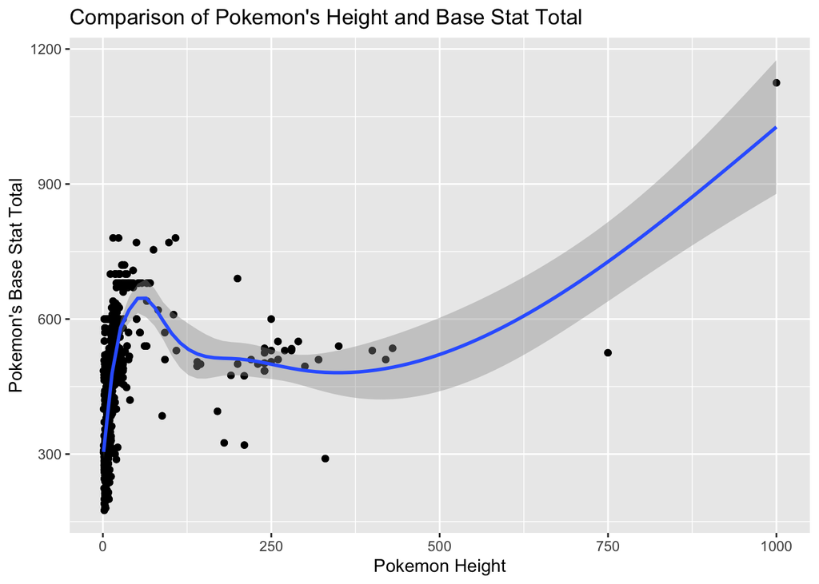

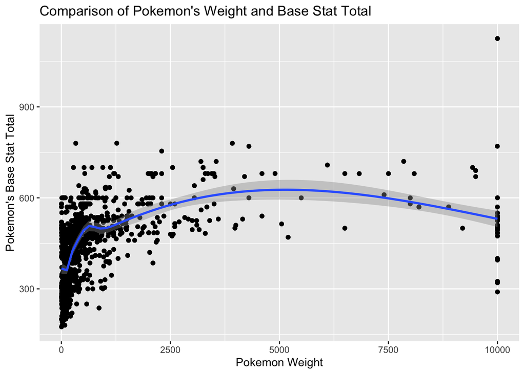

Based on figures that compare height and weight to base stat total, it is unclear if there a connection between them; as such, we will likely omit these from a prediction model for base stat total. We next investigated the relationship between BST and other numeric characteristics, one of which (Capture Rate) is shown below.

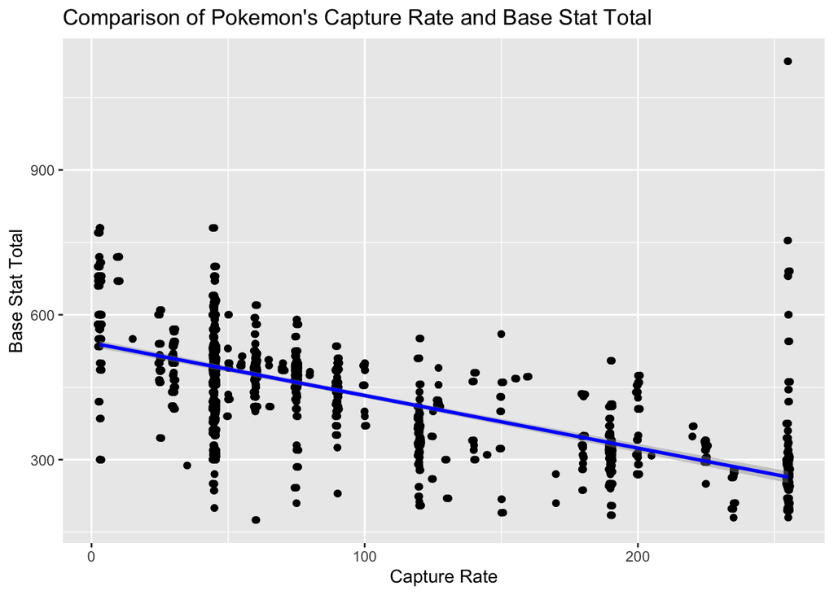

A negative link between capture rate and base stat total is shown in this figure. This implies that Pokemon with a higher base stat total are harder to catch. Characteristics such as this one will be explored in later predictive analyses.

### Competetive Stats Visualization

We first investigated the link between attack and defense, as well as between special attack and special defense. Based on our experience in the games, we predict a negative relationship within these pairs.

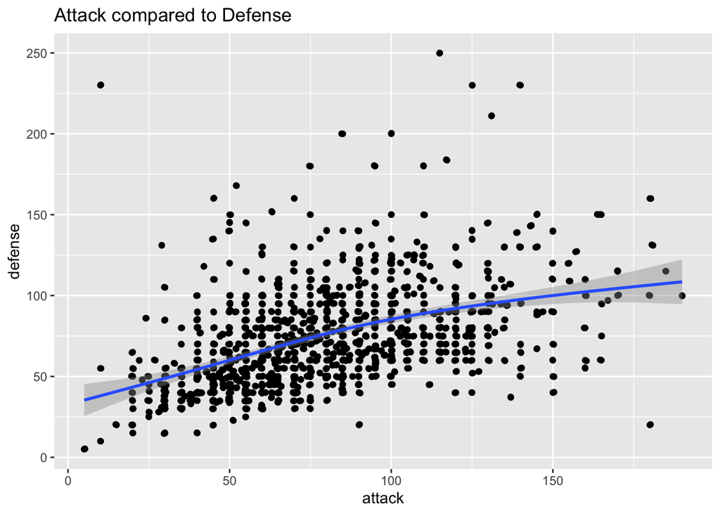

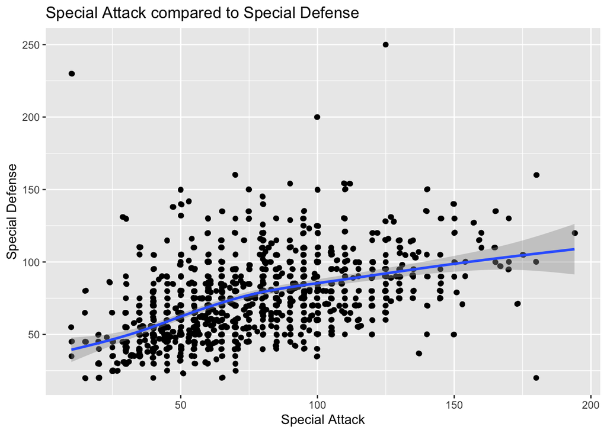

In reality, the pairs show a positive relationship for both normal and special varieties of these statistics.

We were next interested in seeing how a Pokémon’s speed was related to its other stats (hp, attack, defense, special attack, special defense):

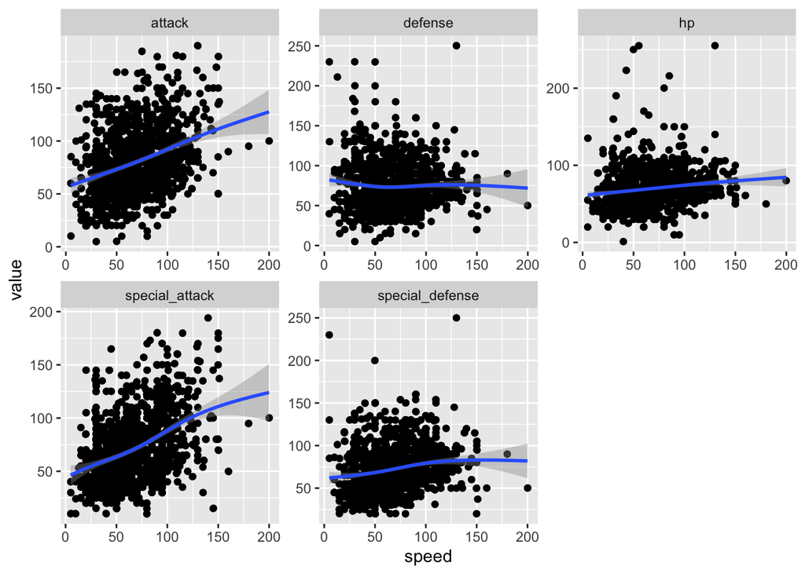

There appears to be a positive link between speed and attack as well as speed and special_attack. The rest of the stats show a neutral link. This topic, similar to the non-stat relationships with BST, will also be touched on in later analyses.

# Statistical Analysis

## Variances Between Stats by ANOVA

Before we formed a predictive model of BST based on a Pokémon’s non-stat characteristics, we first use a one-way ANOVA to test whether there was a difference among the means for the different stats; that is, we wanted to test whether a difference in the population means for each stat was actually built into the game and will carry on for future Pokémon that have not been introduced. We test the following hypotheses:

- H$_0$: There is no difference between the means of all the stats; that is, $\mu_{hp}$ = $\mu_{atk}$ = $\mu_{def}$ = $\mu_{SpA}$ = $\mu_{SpD}$ = $\mu_{Spe}$.
- H$_a$: At least one mean is different from the others; that is, at least one $\mu_i \neq \mu_j$ for $i \neq j$.

The ANOVA test requires several assumptions:

- All observations must be independent of each other; we cannot confirm this but must assume it is true in order for the test to work;
- All distributions are normal, and;
- All distributions have approximately equal variances.

We first examine the normality distributions of all the stats:

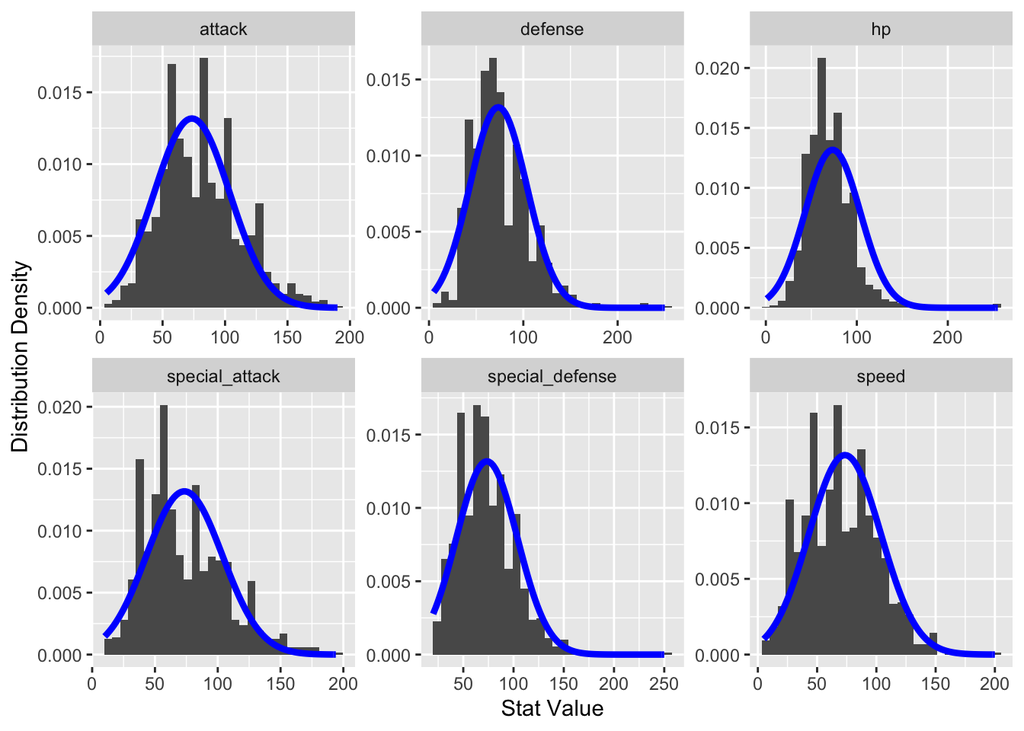

The figure above shows us that with a few exceptions, all the stats are approximately normal. In addition, it is not unreasonable to say that the shape of the curves are generally the same, so the stats likely have sample variances that are not too far apart, but we will test this next.

Sample Variances of Pokémon Stats

| Stat | Sample Variance |
| --- | --- |
| attack | 1,027.59 |
| defense | 958.21 |
| hp | 710.03 |
| special_attack | 1,053.28 |
| special_defense | 771.85 |
| speed | 902.19 |

The largest sample variance observed is 1053.28 (special attack) and the smallest is 710.03 (hp). 1053.28 divided by 710.03 is far less than 3, so we can say that the population variances are around equal. We then move on to the actual ANOVA test and table.

```
##               Df  Sum Sq Mean Sq F value Pr(>F)
## stat           5   91979   18396   20.35 <2e-16 ***
## Residuals   6702 6057647     904
## ---
## Signif. codes:  0 '***' 0.001 '**' 0.01 '*' 0.05 '.' 0.1 ' ' 1
```

The ANOVA table indicates a high F-statistic and low p-value; hence, we say that we reject the null hypothesis and that there is sufficient evidence to conclude at least one of the stats differs from the others and that this difference will carry on for future Pokémon. To determine where this significant difference exists, we perform a Tukey HSD test.

```
##   Tukey multiple comparisons of means
##     95% family-wise confidence level
##
## Fit: aov(formula = value ~ stat, data = stat_comp)
##
## $stat
##                                       diff         lwr        upr     p adj
## defense-attack                  -5.9221825  -9.5468634 -2.2975016 0.0000480
## hp-attack                      -10.6529517 -14.2776326 -7.0282708 0.0000000
## special_attack-attack           -7.4472272 -11.0719081 -3.8225463 0.0000001
## special_defense-attack          -8.1064401 -11.7311210 -4.4817592 0.0000000
## speed-attack                   -11.1994633 -14.8241442 -7.5747824 0.0000000
## hp-defense                      -4.7307692  -8.3554501 -1.1060883 0.0027543
## special_attack-defense          -1.5250447  -5.1497256  2.0996362 0.8373782
## special_defense-defense         -2.1842576  -5.8089385  1.4404233 0.5199470
## speed-defense                   -5.2772809  -8.9019618 -1.6525999 0.0004814
## special_attack-hp                3.2057245  -0.4189564  6.8304054 0.1180602
## special_defense-hp               2.5465116  -1.0781693  6.1711925 0.3407800
## speed-hp                        -0.5465116  -4.1711925  3.0781693 0.9981447
## special_defense-special_attack  -0.6592129  -4.2838938  2.9654680 0.9954755
## speed-special_attack            -3.7522361  -7.3769170 -0.1275552 0.0374607
## speed-special_defense           -3.0930233  -6.7177042  0.5316577 0.1452249
```

The Tukey HSD results indicate that the significant differences at the 0.01 level exist between attack and every other stat, as well as between HP and defense and between speed and defense.

## Linear Regression on Base Stat Total

We next sought to perform a multiple regression to form a linear prediction model for a Pokémon’s base stat total (BST). We did not use the regular stats for this as those variables are highly correlated with BST and would lead to either overfitting or a non-useful regression. Instead, we took the Pokémon’s base experience, capture rate, egg cycles, and base happiness.

```
##
## Call:
## lm(formula = bst ~ base_experience + capture_rate + egg_cycles +
##     base_happiness, data = pokemon)
##
## Residuals:
##     Min      1Q  Median      3Q     Max
## -446.11  -21.68    5.19   24.09  462.23
##
## Coefficients:
##                  Estimate Std. Error t value Pr(>|t|)
## (Intercept)     286.54317    7.59918  37.707  < 2e-16 ***
## base_experience   1.23593    0.02416  51.157  < 2e-16 ***
## capture_rate     -0.21777    0.02267  -9.605  < 2e-16 ***
## egg_cycles        0.04470    0.05860   0.763    0.446
## base_happiness   -0.33664    0.07173  -4.693 3.02e-06 ***
## ---
## Signif. codes:  0 '***' 0.001 '**' 0.01 '*' 0.05 '.' 0.1 ' ' 1
##
## Residual standard error: 43.06 on 1113 degrees of freedom
## Multiple R-squared:  0.8718, Adjusted R-squared:  0.8713
## F-statistic:  1892 on 4 and 1113 DF,  p-value: < 2.2e-16
```

The summary of our multiple regression indicates that while the base experience, capture rate, and base happiness contribute significant information to the linear model at the 0.01 level, the number of egg cycles does not. This somewhat makes sense as the number of egg cycles for a Pokémon remains constant throughout its evolutionary line; for example, Bulbasaur (BST = 318) evolves into Ivysaur (BST = 405) and then Venusaur (BST = 525); yet all of these have 20 egg cycles. High egg cycle number would thus only correspond to high BST for legendary and mythical Pokémon (for example, Arceus has BST 720 and 120 egg cycles).

We then re-calculated the linear model without the number of egg cycles:

```
##
## Call:
## lm(formula = bst ~ base_experience + capture_rate + base_happiness,
##     data = pokemon)
##
## Residuals:
##     Min      1Q  Median      3Q     Max
## -446.79  -21.62    5.52   23.68  463.33
##
## Coefficients:
##                  Estimate Std. Error t value Pr(>|t|)
## (Intercept)     288.55943    7.12335  40.509  < 2e-16 ***
## base_experience   1.24280    0.02241  55.448  < 2e-16 ***
## capture_rate     -0.21827    0.02266  -9.634  < 2e-16 ***
## base_happiness   -0.36318    0.06272  -5.791 9.11e-09 ***
## ---
## Signif. codes:  0 '***' 0.001 '**' 0.01 '*' 0.05 '.' 0.1 ' ' 1
##
## Residual standard error: 43.05 on 1114 degrees of freedom
## Multiple R-squared:  0.8717, Adjusted R-squared:  0.8714
## F-statistic:  2523 on 3 and 1114 DF,  p-value: < 2.2e-16
```

The R$^2$ value for the previous (full) model was 0.8718, while the R$^2$ value for the reduced model was 0.8717; in other words, this is a small reduction and likely makes the model simpler to understand.

Next we verify the additional assumptions required for the linear model; namely:

- The relationship between the predictor variables and the outcome (BST) is linear.
- The residuals from the regression line are nearly normal, and;
- The variability in the residuals is constant.

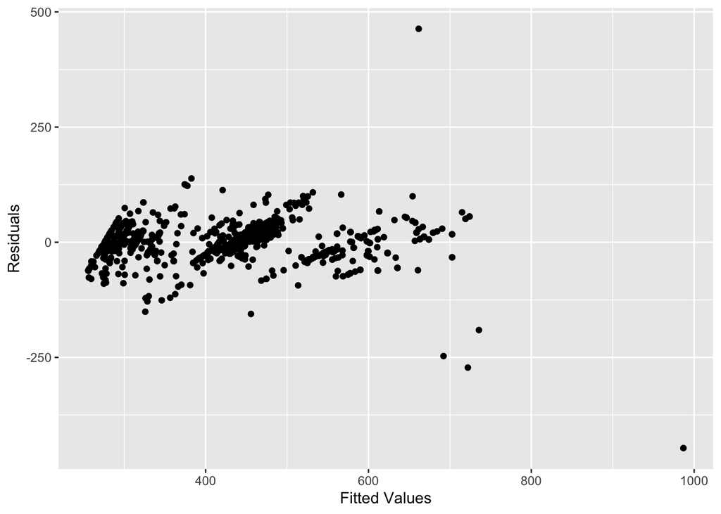

This first plot plots the fitted values versus the residuals and checks to see if there is a linear relation between the predictors and the outcome (BST). Since there is no pattern in the residuals, we see an approximately linear relation. This plot is also used to check constant variability; these residuals are not exactly evenly spread, but the majority are evenly spread in a sector of the plot, indicating that some outliers are likely skewing the results of the regression.

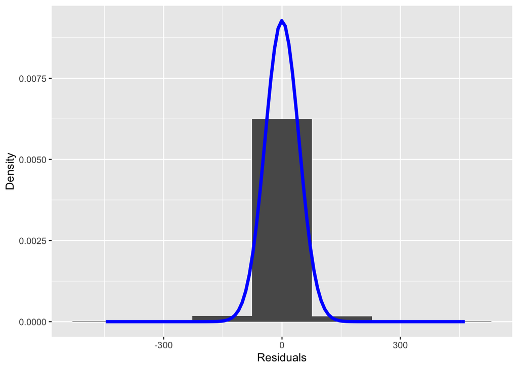

We can see here that the residuals have an approximately normal distribution, which satisfies the normality condition. From this, we conclude that while our model does a decent job with predicting BST based on factors such as base experience, capture rate, and base happiness, it should still be used with some degree of caution, especially when trying to predict incredibly large base stat totals.

## Linear Regression on Speed

We next sought to perform a multiple regression to form a linear prediction model for a Pokémon’s speed. Based on our exploratory data analysis, we decided to use the other competetive stats for this as those variables have various correlations with speed.

```
##
## Call:
## lm(formula = speed ~ attack + defense + special_attack + special_defense +
##     hp, data = pokemon)
##
## Residuals:
##     Min      1Q  Median      3Q     Max
## -83.982 -18.273  -0.498  17.601 112.937
##
## Coefficients:
##                 Estimate Std. Error t value Pr(>|t|)
## (Intercept)     37.30338    2.75368  13.547  < 2e-16 ***
## attack           0.36285    0.02991  12.130  < 2e-16 ***
## defense         -0.30412    0.03237  -9.395  < 2e-16 ***
## special_attack   0.29500    0.02881  10.240  < 2e-16 ***
## special_defense  0.16490    0.03794   4.347 1.51e-05 ***
## hp              -0.11329    0.03393  -3.339 0.000868 ***
## ---
## Signif. codes:  0 '***' 0.001 '**' 0.01 '*' 0.05 '.' 0.1 ' ' 1
##
## Residual standard error: 25.32 on 1112 degrees of freedom
## Multiple R-squared:  0.2925, Adjusted R-squared:  0.2893
## F-statistic: 91.94 on 5 and 1112 DF,  p-value: < 2.2e-16
```

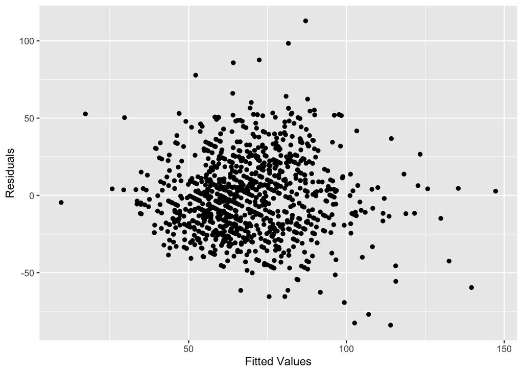

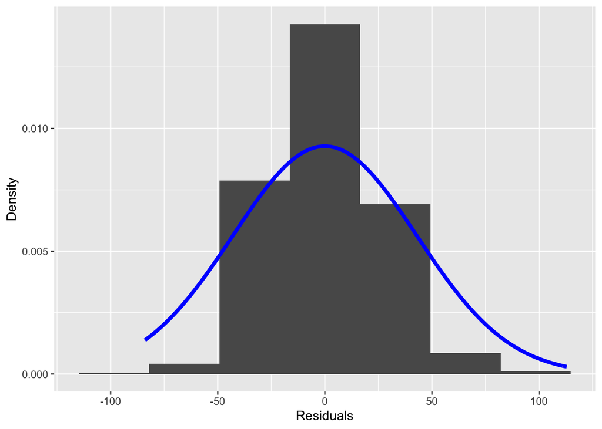

# Conclusion

We found a significant differences at the 0.01 level exist between attack and every other stat, as well as between HP and defense and between speed and defense. Our linear model to predict base stat total does a decent job with predicting BST based on factors such as base experience, capture rate, and base happiness. All the base stats were significant parameters for predicting the Pokemon’s speed with attack and special attack being the most significant positive influencing factors and defense being the most significant negative influencing factor.

The results from our ANOVA analysis and linear regression on speed are important in team-building; knowing that attack significantly differs from every other stat is important in building a team that maximizes each others’ strengths and covers for each others’ weaknesses. For example, Mega Heracross has one of the highest attack stats in the game at 185, but its other stats are mediocre at best. As such, it needs support from defensive Pokémon like Toxapex and/or fast Pokémon like Deoxys-Speed.

In addition, our linear regression on BST shows that with some exceptions, BST can be somewhat accurately predicted based on non-stat characteristics of Pokémon. While we cannot confirm that this was included into the games by design, we are inclined to believe that such a link is envisioned by the Pokémon developers. It makes sense for more powerful Pokémon to be harder to catch and harder to befriend, and it shows that there is a lot more that goes into the games and into Pokémon design than what is shown on the surface level.